# LSABD group project – Part 1: exploration, preprocessing and quality control of NHANES 2021–2023

Group …

2026-11-26

# Aim of this notebook

This notebook carries out **part 1** of the project plan (steps 1.1–1.12): it prepares the NHANES 2021–2023 dataset for the analyses in parts 2–4. The theme of our project is **obesity in US adults**: who is at risk (part 2), which laboratory profile accompanies it (part 3), and whether it can be predicted from that profile (part 4). Following the guiding questions of the assignment, we:

| Step | What | Why |
| --- | --- | --- |
| 1.1 | Load the data and check the file | First make sure the data are read correctly (lesson 2) |
| 1.2 | Structure and variable types | Guiding question 1; the type decides which model fits |
| 1.3 | Study population | BMI cut-offs apply to adults only; pregnancy changes weight and blood values |
| 1.4 | Special codes and top-coding | Otherwise codes such as 999 are treated as real values |
| 1.5 | Derived and recoded variables | Outcome and covariates for parts 2–4 |
| 1.6 | Descriptive statistics | Get to know each variable first (lesson 2) |
| 1.7 | Missing values | Guiding question 2; is a complete-case analysis reliable? |
| 1.8 | Selection of laboratory features | Remove uninformative features without using group labels (part 3) |
| 1.9 | Normalisation and log2 transformation | Symmetric distributions for linear models |
| 1.10 | Outliers | Guiding question 3: technical error or biology? |
| 1.11 | Standardisation, PCA and clustering | Guiding question 5: biology or technical factor? |
| 1.12 | Save the preprocessed data | Parts 2–4 start from the same data |

Every preprocessing decision is motivated in the text directly above or below the code that implements it. The chunks can be run one by one in RStudio (green arrow) or all at once with **Knit**.

## Research framework

Following the structure of lesson 1 (goal, aim, question, hypothesis, objectives):

[output not shown]

The study is **cross-sectional** (all variables measured at one visit): we can study associations, not cause and effect.

## Order of the preprocessing steps

We follow the order recommended in lesson 2: **inspect the data → handle missing values (filter or impute) → normalise → log-transform → standardise**, followed by quality control with visualisations (heatmap with clustering, PCA). Batch correction (optional step 4 of lesson 2) is only needed if the quality control reveals a technical effect.

# Step 0: setup

*What: load the packages and set the paths. Why: all later steps use them; change only `data_dir` on your own computer.*

```r
library(tidyverse)       # data wrangling and ggplot2
library(ggpubr)          # QQ plots and arranging plots
library(ComplexHeatmap)  # correlation heatmap

theme_set(theme_classic())
```

Change `data_dir` to the folder that contains the two csv files on your own computer. All other paths are built from it.

```r
data_dir <- "C:/Users/achil/Documents/GitHub/GroupProject_LargeScale/data"

# Folder for the preprocessed data and tables (created if it does not exist)
output_dir <- file.path(data_dir, "output")
dir.create(output_dir, showWarnings = FALSE)
```

# Step 1.1: load the data and check the file

*What: read the data and the codebook, check identifiers and parsing problems. Why: lesson 2 — first make sure the data are read correctly before analysing.*

Two files were provided:

- `NHANES_20212023_merged_filtered 1.csv`: the data. One row per participant (`SEQN`), one column per variable. Several NHANES 2021–2023 files (demographics, examination, laboratory, questionnaire) were merged on `SEQN`.
- `NHANES_20212023_codebook_filtered 1.csv`: one row per column of the data, with a readable label, the original NHANES file and the component.

`guess_max` is set high because many columns are empty in the first rows (e.g. subsample measurements). With the default (1000 rows), `read_csv()` could guess such a column as “logical” and silently turn the later values into `NA`. The codebook contains a few non-UTF-8 characters (e.g. µ), so it is read as latin1.

```r
nhanes_raw <- read_csv(file.path(data_dir, "NHANES_20212023_merged_filtered 1.csv"),
                       guess_max = 12000, show_col_types = FALSE)
codebook <- read_csv(file.path(data_dir, "NHANES_20212023_codebook_filtered 1.csv"),
                     locale = locale(encoding = "latin1"), show_col_types = FALSE)

dim(nhanes_raw)
```

```
## [1] 11933   486
```

```r
dim(codebook)
```

```
## [1] 486   4
```

```r
# Does the codebook describe exactly the columns of the data, in the same order?
all(colnames(nhanes_raw) == codebook$variable)
```

```
## [1] TRUE
```

```r
# Is every participant present only once?
anyDuplicated(nhanes_raw$SEQN) == 0
```

```
## [1] TRUE
```

```r
# Parsing problems, e.g. text in a numeric column or a wrong decimal separator
nrow(problems(nhanes_raw))
```

```
## [1] 0
```

Before any analysis, lesson 2 recommends checking how the file is built. The data are comma-separated with a dot as decimal separator, every participant has a unique identifier (`SEQN`), and `read_csv()` reports no parsing problems, so no column contains text where a number is expected. Missing values are stored as empty fields, which `read_csv()` converts to `NA`. However, NHANES also uses numeric codes for “refused” and “don’t know” (e.g. 7/9, 77/99), which R does not recognise as missing; we recode them in step 1.4.

# Step 1.2: structure and variable types

*What: count samples and features, classify every variable. Why: guiding question 1; the variable type decides which model fits later.*

## Samples and features

The raw data contain 11,933 participants and 486 variables. The codebook groups the variables into four NHANES components:

```r
codebook %>% count(component, sort = TRUE)
```

```
## # A tibble: 4 × 2
##   component         n
##   <chr>         <int>
## 1 Laboratory      387
## 2 Questionnaire    40
## 3 Examination      32
## 4 Demographics     27
```

```r
codebook %>%
  count(component, file, name = "n_variables") %>%
  arrange(component, desc(n_variables))
```

```
## # A tibble: 38 × 3
##    component    file     n_variables
##    <chr>        <chr>          <int>
##  1 Demographics DEMO_L            27
##  2 Examination  BMX_L             21
##  3 Examination  BPXO_L            11
##  4 Laboratory   VOCWB_L           77
##  5 Laboratory   FAR_L             43
##  6 Laboratory   BIOPRO_L          41
##  7 Laboratory   TST_L             34
##  8 Laboratory   CBC_L             22
##  9 Laboratory   PFAS_L            19
## 10 Laboratory   FASTQX_L          18
## # ℹ 28 more rows
```

Almost all columns are stored as numbers, also the categorical ones: NHANES codes categories as integers (e.g. `RIAGENDR`: 1 = male, 2 = female). The only text column is `BPAOARM` (arm used for the blood pressure measurement, “R”/“L”).

```r
table(sapply(nhanes_raw, class))
```

```
##
## character   logical   numeric
##         1         1       484
```

## Variable types

The codebook does not tell us the variable type. As a first overview of **all** 486 variables, we classify them by their role and by the number of distinct values:

- identifier, survey design variables and comment codes are recognised from their name or label;
- variables with only 2 distinct values are binary;
- variables with 3–15 distinct values are integer codes for categories;
- variables with more than 15 distinct values are numeric measurements.

```r
n_values <- sapply(nhanes_raw, function(x) length(unique(na.omit(x))))

type_tbl <- codebook %>%
  mutate(n_values = n_values[variable],
         type = case_when(
           variable == "SEQN" ~ "identifier",
           str_starts(variable, "WT") | str_starts(variable, "SDMV") ~ "survey design (weight, stratum, PSU)",
           str_detect(label, regex("comment|cmt|comt", ignore_case = TRUE)) ~ "comment code (quality flag)",
           n_values <= 1 ~ "constant or empty",
           n_values == 2 ~ "binary (nominal)",
           n_values <= 15 ~ "categorical codes (nominal or ordinal)",
           TRUE ~ "numeric (continuous or discrete)"))

table(type_tbl$type, type_tbl$component)
```

```
##
##                                          Demographics Examination Laboratory
##   binary (nominal)                                  5           1          9
##   categorical codes (nominal or ordinal)           12           3         27
##   comment code (quality flag)                       0           9        114
##   constant or empty                                 1           0          4
##   identifier                                        1           0          0
##   numeric (continuous or discrete)                  4          19        206
##   survey design (weight, stratum, PSU)              4           0         27
##
##                                          Questionnaire
##   binary (nominal)                                   2
##   categorical codes (nominal or ordinal)            25
##   comment code (quality flag)                        0
##   constant or empty                                  5
##   identifier                                         0
##   numeric (continuous or discrete)                   8
##   survey design (weight, stratum, PSU)               0
```

```r
# Variables without any information
type_tbl %>% filter(type == "constant or empty") %>% select(variable, label, n_values)
```

```
## # A tibble: 10 × 3
##    variable label                                  n_values
##    <chr>    <chr>                                     <int>
##  1 SDDSRVYR Data release cycle                            1
##  2 LBDHD    Hepatitis D antibody (anti-HDV)               1
##  3 LBXV1D   Blood 1,2-Dichlorobenzene (ng/mL)             1
##  4 LBXV3B   Blood 1,3-Dichlorobenzene (ng/mL)             1
##  5 LBXVTP   Blood 1,2,3-Trichloropropane (ng/mL)          1
##  6 DBQ073B  Type of milk first fed - 2% milk              1
##  7 DBQ073C  Type of milk first fed - 1% milk              1
##  8 DBQ073D  Type of milk first fed - fat free milk        1
##  9 DBQ073E  Type of milk first fed - soy milk             1
## 10 DBQ073U  Type of milk first fed - other                1
```

| variable | description | type |
| --- | --- | --- |
| SEQN | Participant identifier | identifier (not a feature) |
| RIAGENDR | Sex (1 = male, 2 = female) | nominal (binary) |
| RIDRETH3 | Race/Hispanic origin incl. NH Asian | nominal (6 categories) |
| DMDEDUC2 | Education level, adults 20+ | ordinal (5 levels) |
| RIDEXMON | Six-month exam period (Nov–Apr / May–Oct) | nominal (binary) |
| PHDSESNZ | Exam session (morning / afternoon-evening) | nominal (binary) |
| RIDAGEYR | Age in years (top-coded at 80) | discrete (continuous in practice) |
| INDFMPIR | Family income-to-poverty ratio (top-coded at 5) | continuous |
| ALQ121 | Alcohol frequency past 12 months (0–10 categories) | ordinal |
| ALQ130 | Average number of drinks per drinking day | discrete (count) |
| BMXBMI | Body mass index (kg/m²) | continuous |
| BPXOSY1-3 | Systolic blood pressure, 3 readings | continuous |
| LBX… | Laboratory measurements | continuous (mostly right-skewed) |
| LBD…LC | Laboratory comment codes (0 = at/above, 1 = below detection limit) | nominal (binary), quality flag |
| WT… | Survey sample weights | design variable (not a feature) |

# Step 1.3: study population

*What: keep interviewed and examined adults (≥ 20 years) who are not pregnant. Why: BMI cut-offs only apply to adults; pregnancy changes weight and blood values; without examination there are no measurements.*

We restrict the analyses to:

1. **participants who were interviewed and examined** (`RIDSTATR` = 2). The 3,073 participants who were only interviewed have no body measurements, blood pressure or laboratory data.
2. **adults aged 20 years or older**. Children have different reference values for BMI and blood pressure and are not asked most adult questions. Education (`DMDEDUC2`) is only available from age 20, and Flegal et al. (2010) use the same cut-off.
3. **non-pregnant participants** (`RIDEXPRG` ≠ 1). Pregnancy strongly changes body weight, blood volume and many laboratory values (e.g. hormones, hemoglobin). Flegal et al. also excluded pregnant women.

`!(RIDEXPRG %in% 1)` keeps participants with a missing pregnancy status (all men and women outside the 20–44 age range in which the question is asked).

```r
flow <- tibble(
  step = c("All participants",
           "Interviewed and examined (RIDSTATR = 2)",
           "... and aged 20 years or older",
           "... and not pregnant"),
  n = c(nrow(nhanes_raw),
        sum(nhanes_raw$RIDSTATR == 2),
        sum(nhanes_raw$RIDSTATR == 2 & nhanes_raw$RIDAGEYR >= 20),
        sum(nhanes_raw$RIDSTATR == 2 & nhanes_raw$RIDAGEYR >= 20 &
              !(nhanes_raw$RIDEXPRG %in% 1)))
)
knitr::kable(flow)
```

| step | n |
| --- | --- |
| All participants | 11933 |
| Interviewed and examined (RIDSTATR = 2) | 8860 |
| … and aged 20 years or older | 6064 |
| … and not pregnant | 6023 |

```r
nhanes <- nhanes_raw %>%
  filter(RIDSTATR == 2, RIDAGEYR >= 20, !(RIDEXPRG %in% 1))
```

The study population contains **6,023 adults**.

# Step 1.4: special codes and top-coding

*What: recode “refused”/“don’t know” codes to `NA` and count top-coded values. Why: otherwise R treats e.g. “999 drinks” as a real value.*

## Special codes

In the questionnaire and demographic variables, NHANES uses codes such as 7/77/777 (“refused”) and 9/99/999 (“don’t know”). They look like numbers but are not measurements: an average number of 999 drinks per day is meaningless. The code depends on the number of digits of the variable, so we first inspect the values and then define the codes per variable.

```r
# Example: the codes only appear as a separate group of values far above the real range
table(nhanes$DMDEDUC2, useNA = "ifany")
```

```
##
##    1    2    3    4    5    9
##  292  479 1283 1836 2129    4
```

```r
table(nhanes$ALQ130, useNA = "ifany")
```

```
##
##    1    2    3    4    5    6    7    8    9   10   11   12   14   15  777  999
## 1309 1271  570  235  199  135   15   41   18   29    4   52    2   20    3   10
## <NA>
## 2110
```

```r
special_codes <- list(
  DMDEDUC2 = c(7, 9),     DMDMARTZ = c(77, 99),   DMDBORN4 = c(77, 99),
  DMQMILIZ = c(7, 9),     DMDYRUSR = c(77, 99),   ALQ111   = c(7, 9),
  ALQ121   = c(77, 99),   ALQ130   = c(777, 999), ALQ142   = c(77, 99),
  ALQ270   = c(77, 99),   ALQ280   = c(77, 99),   ALQ151   = c(7, 9),
  ALQ170   = c(777, 999)
)

# Count how many values will be recoded, before recoding them
recode_summary <- tibble(
  variable  = names(special_codes),
  codes     = map_chr(special_codes, ~ paste(.x, collapse = "/")),
  n_recoded = map_int(names(special_codes), ~ sum(nhanes[[.x]] %in% special_codes[[.x]]))
)
knitr::kable(recode_summary)
```

| variable | codes | n_recoded |
| --- | --- | --- |
| DMDEDUC2 | 7/9 | 4 |
| DMDMARTZ | 77/99 | 4 |
| DMDBORN4 | 77/99 | 0 |
| DMQMILIZ | 7/9 | 0 |
| DMDYRUSR | 77/99 | 33 |
| ALQ111 | 7/9 | 5 |
| ALQ121 | 77/99 | 5 |
| ALQ130 | 777/999 | 13 |
| ALQ142 | 77/99 | 20 |
| ALQ270 | 77/99 | 13 |
| ALQ280 | 77/99 | 10 |
| ALQ151 | 7/9 | 5 |
| ALQ170 | 777/999 | 5 |

```r
# Replace the special codes by NA
for (v in names(special_codes)) {
  nhanes[[v]][nhanes[[v]] %in% special_codes[[v]]] <- NA
}
```

Only a few values per variable are affected (at most 33, for the time living in the US). Because they are so rare, we simply treat them as missing.

## Top-coding

Two variables are top-coded for privacy reasons. These are not errors, but they limit the interpretation:

- `RIDAGEYR` = 80 means “80 years or older” (342 participants);
- `INDFMPIR` = 5 means “income at least 5 times the poverty level” (1322 participants).

We keep these participants, with their top-coded value:

- They are real, valid measurements: someone with value 80 is truly at least 80 years old. Only the exact value is hidden, which is a choice of NHANES to protect privacy, not a measurement error.
- Removing them would throw away 342 adults (5.7%) aged 80 or older and 1,322 adults (25.2% of those with an income value) with the highest incomes.
- The sample would then no longer contain the oldest and the richest participants, which would bias every comparison.
- Setting them to NA would create missing values that depend on the value itself (MNAR), the most problematic type of missingness. Imputing a “true” value would only be a guess.

The consequence is that differences within the top group (e.g. between 82 and 90 years) cannot be seen, so a linear effect of age or income in a regression model may be slightly distorted at the top of the range. For income this concerns a quarter of the participants, so in part 2 we will also use income categories (ratio < 1.3, 1.3–3.5 and ≥ 3.5). In categories, the top-coding no longer matters.

# Step 1.5: derived and recoded variables

*What: readable factors, mean blood pressure, BMI categories, obesity, abdominal obesity and smoking status. Why: needed as outcome and covariates in parts 2–4.*

We convert the coded categorical variables to factors with readable labels, and derive the variables needed in parts 2–4:

- **Race/ethnicity**: non-Hispanic White, the largest group, is the reference level, as in Flegal et al.
- **Education** is an ordered factor.
- **Blood pressure**: the mean of the (up to) three oscillometric readings, as in Micha et al. `rowMeans()` returns `NaN` when all three readings are missing; we turn that into `NA`.
- **BMI categories** use the WHO cut-offs: overweight 25–29.9, obesity ≥ 30. Obesity (BMI ≥ 30) is the outcome of part 2 and the contrast of part 3.
- **Abdominal obesity**: waist circumference > 102 cm in men or > 88 cm in women. BMI does not show where fat is stored, so this alternative definition will be used as a sensitivity analysis.
- **Smoking status** is derived from serum cotinine, a breakdown product of nicotine: cotinine ≥ 3 ng/mL = current smoker. This objective measure does not depend on self-report. Cotinine was not kept as a laboratory feature (step 1.8: a large share of the values is below the detection limit, which is exactly what makes it a good marker of non-smoking). Smoking is a confounder in part 3, because it affects inflammation markers and white blood cells.

```r
nhanes <- nhanes %>%
  mutate(
    sex       = factor(RIAGENDR, levels = c(1, 2), labels = c("Male", "Female")),
    race_eth  = factor(RIDRETH3, levels = c(3, 1, 2, 4, 6, 7),
                       labels = c("NH White", "Mexican American", "Other Hispanic",
                                  "NH Black", "NH Asian", "Other/multiracial")),
    education = factor(DMDEDUC2, levels = 1:5, ordered = TRUE,
                       labels = c("<9th grade", "9-11th grade", "High school/GED",
                                  "Some college/AA", "College graduate+")),
    age_group = cut(RIDAGEYR, breaks = c(20, 40, 60, Inf), right = FALSE,
                    labels = c("20-39", "40-59", "60+")),
    exam_period  = factor(RIDEXMON, levels = c(1, 2), labels = c("Nov-Apr", "May-Oct")),
    # PHDSESNZ: 0 = morning, 1 = afternoon/evening (FASTQX_L documentation)
    exam_session = factor(PHDSESNZ, levels = c(0, 1), labels = c("Morning", "Afternoon/evening")),
    sbp = rowMeans(pick(BPXOSY1, BPXOSY2, BPXOSY3), na.rm = TRUE),
    dbp = rowMeans(pick(BPXODI1, BPXODI2, BPXODI3), na.rm = TRUE),
    sbp = if_else(is.nan(sbp), NA_real_, sbp),
    dbp = if_else(is.nan(dbp), NA_real_, dbp),
    bmi_cat = cut(BMXBMI, breaks = c(0, 18.5, 25, 30, Inf), right = FALSE,
                  labels = c("Underweight", "Normal weight", "Overweight", "Obese")),
    obese = factor(if_else(BMXBMI >= 30, "Obese", "Not obese"),
                   levels = c("Not obese", "Obese")),
    abdominal_obese = factor(
      if_else((sex == "Male" & BMXWAIST > 102) | (sex == "Female" & BMXWAIST > 88),
              "Abdominal obesity", "No abdominal obesity"),
      levels = c("No abdominal obesity", "Abdominal obesity")),
    smoker = factor(if_else(LBXCOT >= 3, "Smoker", "Non-smoker"),
                    levels = c("Non-smoker", "Smoker"))
  )

# Sample sizes per group
nhanes %>% count(sex)
```

```
## # A tibble: 2 × 2
##   sex        n
##   <fct>  <int>
## 1 Male    2720
## 2 Female  3303
```

```r
nhanes %>% count(race_eth)
```

```
## # A tibble: 6 × 2
##   race_eth              n
##   <fct>             <int>
## 1 NH White           3550
## 2 Mexican American    401
## 3 Other Hispanic      608
## 4 NH Black            743
## 5 NH Asian            335
## 6 Other/multiracial   386
```

```r
nhanes %>% count(age_group)
```

```
## # A tibble: 3 × 2
##   age_group     n
##   <fct>     <int>
## 1 20-39      1519
## 2 40-59      1732
## 3 60+        2772
```

```r
nhanes %>% count(bmi_cat)
```

```
## # A tibble: 5 × 2
##   bmi_cat           n
##   <fct>         <int>
## 1 Underweight      82
## 2 Normal weight  1505
## 3 Overweight     1903
## 4 Obese          2439
## 5 <NA>             94
```

```r
nhanes %>% count(smoker)
```

```
## # A tibble: 3 × 2
##   smoker         n
##   <fct>      <int>
## 1 Non-smoker  4206
## 2 Smoker      1279
## 3 <NA>         538
```

```r
# Agreement between the two obesity definitions
table(BMI = nhanes$obese, waist = nhanes$abdominal_obese)
```

```
##            waist
## BMI         No abdominal obesity Abdominal obesity
##   Not obese                 2164              1218
##   Obese                       58              2269
```

# Step 1.6: descriptive statistics

*What: summary statistics, histograms, bar charts and bivariate relations. Why: lesson 2 — get to know each variable on its own before analysing.*

## Continuous variables

As in the exploration workflow of lesson 2, we first describe each variable on its own: central tendency (mean, median), spread (SD, quartiles, range) and distribution (histograms).

```r
continuous_vars <- c(`Age (years)` = "RIDAGEYR", `BMI (kg/m²)` = "BMXBMI",
                     `Waist circumference (cm)` = "BMXWAIST",
                     `Systolic BP (mmHg)` = "sbp", `Diastolic BP (mmHg)` = "dbp",
                     `Income-to-poverty ratio` = "INDFMPIR")

desc_tbl <- map_dfr(names(continuous_vars), function(lab) {
  x <- nhanes[[continuous_vars[[lab]]]]
  tibble(variable = lab,
         n = sum(!is.na(x)), n_missing = sum(is.na(x)),
         mean = mean(x, na.rm = TRUE), sd = sd(x, na.rm = TRUE),
         median = median(x, na.rm = TRUE),
         Q1 = quantile(x, 0.25, na.rm = TRUE), Q3 = quantile(x, 0.75, na.rm = TRUE),
         min = min(x, na.rm = TRUE), max = max(x, na.rm = TRUE))
})
knitr::kable(desc_tbl, digits = 1)
```

| variable | n | n_missing | mean | sd | median | Q1 | Q3 | min | max |
| --- | --- | --- | --- | --- | --- | --- | --- | --- | --- |
| Age (years) | 6023 | 0 | 54.0 | 17.1 | 58.0 | 39.0 | 68.0 | 20.0 | 80.0 |
| BMI (kg/m²) | 5929 | 94 | 29.8 | 7.4 | 28.5 | 24.7 | 33.6 | 11.1 | 74.8 |
| Waist circumference (cm) | 5726 | 297 | 101.1 | 16.9 | 99.5 | 88.9 | 111.4 | 60.0 | 187.0 |
| Systolic BP (mmHg) | 5824 | 199 | 123.0 | 18.1 | 120.7 | 110.7 | 132.7 | 70.0 | 232.3 |
| Diastolic BP (mmHg) | 5824 | 199 | 74.8 | 11.0 | 74.0 | 67.3 | 81.3 | 34.0 | 139.0 |
| Income-to-poverty ratio | 5236 | 787 | 2.9 | 1.7 | 2.8 | 1.4 | 5.0 | 0.0 | 5.0 |

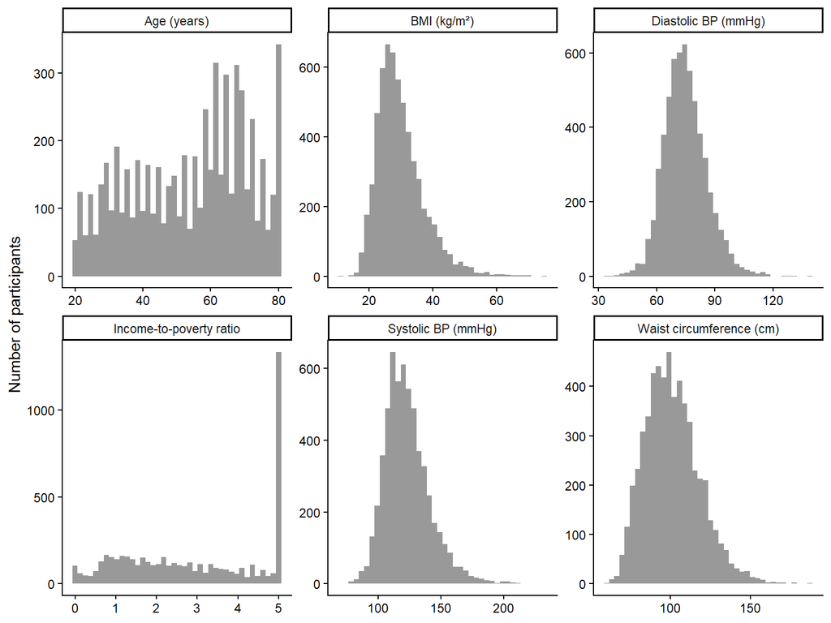

```r
nhanes %>%
  select(all_of(continuous_vars)) %>%
  pivot_longer(everything(), names_to = "variable", values_to = "value") %>%
  drop_na(value) %>%
  ggplot(aes(x = value)) +
  geom_histogram(bins = 40, fill = "grey60") +
  facet_wrap(~ variable, scales = "free", ncol = 3) +
  labs(x = NULL, y = "Number of participants")
```

The mean BMI is 29.8 kg/m² (median 28.5): the average participant is overweight. BMI and waist circumference are slightly right-skewed (a tail of severe obesity). The income-to-poverty ratio shows a peak at 5 because of top-coding (step 1.4), and age a peak at 80 for the same reason.

## Categorical variables

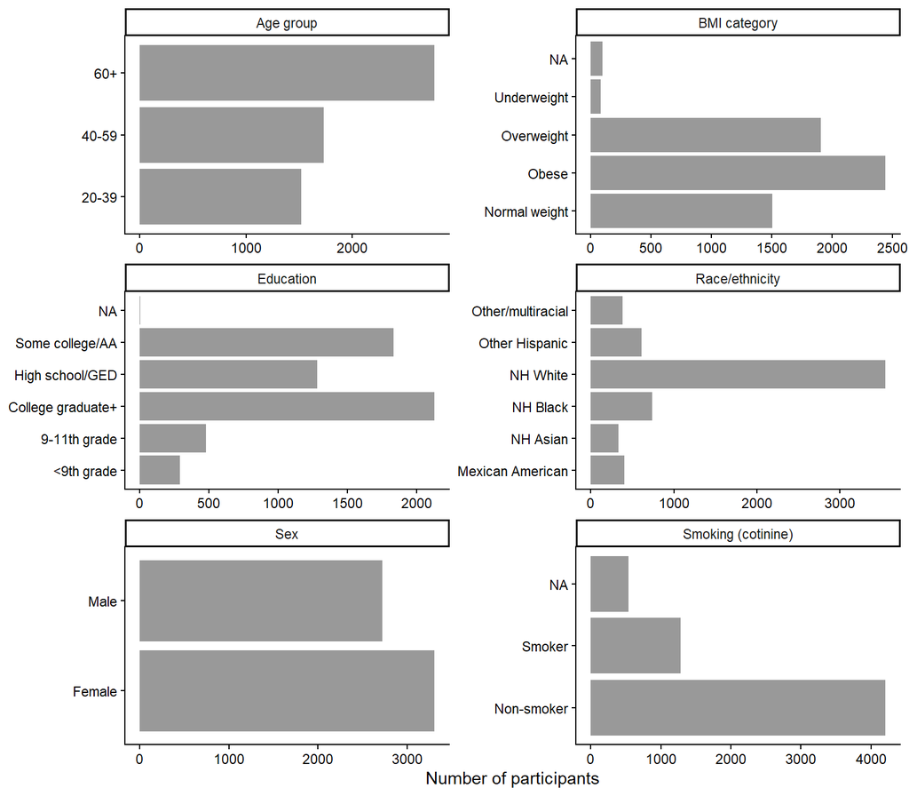

```r
categorical_vars <- c(Sex = "sex", `Race/ethnicity` = "race_eth", Education = "education",
                      `Age group` = "age_group", `BMI category` = "bmi_cat",
                      `Smoking (cotinine)` = "smoker")

nhanes %>%
  select(all_of(categorical_vars)) %>%
  mutate(across(everything(), as.character)) %>%
  pivot_longer(everything(), names_to = "variable", values_to = "category") %>%
  ggplot(aes(y = category)) +
  geom_bar(fill = "grey60") +
  facet_wrap(~ variable, scales = "free", ncol = 2) +
  labs(x = "Number of participants", y = NULL)
```

All groups are large enough for the analyses in parts 2–4. The smallest race/ethnicity group (non-Hispanic Asian) still contains more than 300 adults with a BMI. `NA` in the bar charts are missing values (e.g. no cotinine measurement).

## Relations between variables

Bivariate exploration (lesson 2: correlation analysis and scatter plots) shows which variables carry overlapping information. Strongly correlated explanatory variables should not be combined in one regression model (collinearity, lesson 3).

```r
round(cor(nhanes[, continuous_vars], use = "pairwise.complete.obs", method = "spearman"), 2)
```

```
##          RIDAGEYR BMXBMI BMXWAIST   sbp   dbp INDFMPIR
## RIDAGEYR     1.00   0.02     0.17  0.39 -0.06     0.06
## BMXBMI       0.02   1.00     0.90  0.06  0.23    -0.07
## BMXWAIST     0.17   0.90     1.00  0.14  0.23    -0.04
## sbp          0.39   0.06     0.14  1.00  0.58    -0.03
## dbp         -0.06   0.23     0.23  0.58  1.00    -0.02
## INDFMPIR     0.06  -0.07    -0.04 -0.03 -0.02     1.00
```

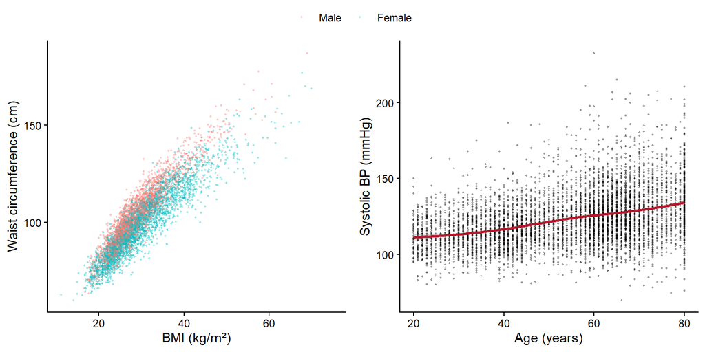

```r
ggarrange(
  ggplot(nhanes, aes(x = BMXBMI, y = BMXWAIST, colour = sex)) +
    geom_point(size = 0.4, alpha = 0.3) +
    labs(x = "BMI (kg/m²)", y = "Waist circumference (cm)", colour = NULL),
  ggplot(nhanes, aes(x = RIDAGEYR, y = sbp)) +
    geom_point(size = 0.4, alpha = 0.3) +
    geom_smooth(method = "loess", colour = "#B2182B") +
    labs(x = "Age (years)", y = "Systolic BP (mmHg)"),
  ncol = 2, common.legend = TRUE
)
```

BMI and waist circumference are very strongly correlated, so we use them as alternative definitions of obesity and never together in one model. Systolic blood pressure rises with age, which illustrates why age is a confounder in many of our analyses.

# Step 1.7: missing values

*What: where values are missing, why (MCAR/MAR/MNAR), and whether the complete cases are representative. Why: guiding question 2.*

## Overview: how missing values are handled per analysis

We do not impute (the reasons are given at the end of this step). A participant with a missing value in a variable of an analysis therefore drops out of **that** analysis. Dropping participants is only a problem if the ones who drop out differ systematically from the others: then the remaining sample is no longer representative and the result can be biased.

So the rule we follow is: **for each analysis, look at the variables in its model, see how many participants drop out because of missing values in them, and check the dropouts where there are many.** A variable with only a few missing values (e.g. 4 for education) cannot bias the result; a variable with hundreds of missing values can.

| Analysis | Variables in the model | % missing | Participants left | Where checked |
| --- | --- | --- | --- | --- |
| All parts | laboratory panels measured in a subsample (PFAS, VOCs, fasting panels) | 50–80% | not used | removed by the feature filter (step 1.8) |
| Part 2 | obesity (BMI), race/ethnicity, sex, age, education | 0–1.6% | — | too few missing to matter |
| Part 2 | **income** | **13.1%** | 5,156 of 5,929 | **income check below** |
| Part 3 | 20 blood markers + cotinine (smoking) | together 12% | 5,190 of 5,929 | complete-case check below |
| Part 4 | 101 blood markers | up to 11% per marker | to be decided in part 4 | imputation fitted on the training set, or complete cases |

The two checks below therefore cover the two analyses where many participants drop out: income in part 2 and the blood markers in part 3.

## Where are the missing values?

We calculate the percentage of missing values of every variable in the study population and summarise it per NHANES file.

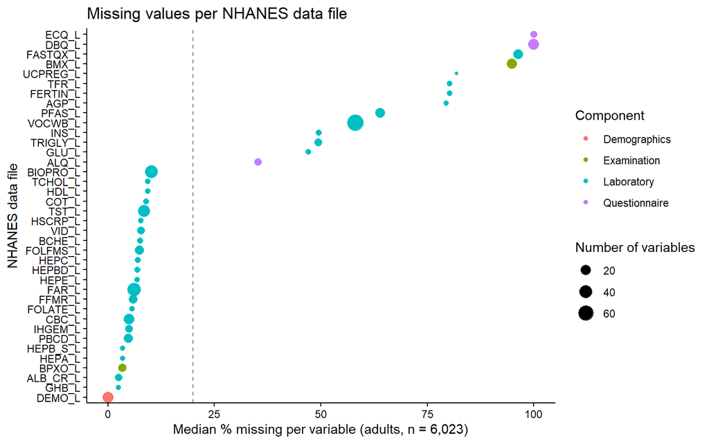

```r
missing_tbl <- tibble(variable    = colnames(nhanes_raw),
                      pct_missing = colMeans(is.na(nhanes[, colnames(nhanes_raw)])) * 100) %>%
  left_join(codebook, by = "variable")

missing_by_file <- missing_tbl %>%
  group_by(component, file) %>%
  summarise(median_pct_missing = median(pct_missing), n_variables = n(), .groups = "drop")

ggplot(missing_by_file,
       aes(x = median_pct_missing, y = reorder(file, median_pct_missing), colour = component)) +
  geom_point(aes(size = n_variables)) +
  geom_vline(xintercept = 20, linetype = "dashed", colour = "grey50") +
  labs(x = "Median % missing per variable (adults, n = 6,023)",
       y = "NHANES data file", colour = "Component", size = "Number of variables",
       title = "Missing values per NHANES data file")
```

## Why are they missing?

Most of the missing values are **missing by design** (planned missingness), not because of a measurement problem:

- **Subsamples**: some laboratory panels are measured only in a random subsample. The fasting panels (`TRIGLY_L`: triglycerides and LDL; `GLU_L`: fasting glucose; `INS_L`: insulin) are only measured in participants examined in the morning session after an overnight fast (~50% missing). Volatile organic compounds (`VOCWB_L`) and PFAS (`PFAS_L`) are measured in a random subsample of roughly 35–40% of the participants (~60–65% missing).
- **Age- or sex-specific components**: ferritin, transferrin receptor and alpha-1-acid glycoprotein (`FERTIN_L`, `TFR_L`, `AGP_L`) and the urine pregnancy test are only measured in specific age/sex groups. The infant-feeding (`DBQ_L`) and early-childhood (`ECQ_L`) questions are about children and are therefore almost completely empty for adults.
- **Skip patterns** in questionnaires: for example, `ALQ130` (drinks per day) is only asked to people who drank alcohol in the past year.
- **Non-participation in a component**: 293 adults (4.9%) have no blood measurements (e.g. no blood draw). They are similar to the other participants in mean age (51.2 vs 54.2 years) and sex (54.3% vs 54.9% women).

Because subsample selection is random, the missingness in the subsample panels can be considered missing completely at random (MCAR) with respect to the participants’ characteristics. Imputing a panel that is missing for 50–80% of the participants would mostly create artificial data. We therefore **do not impute**, but select variables with a low proportion of missing values (step 1.8) and use complete cases per analysis. The age and sex comparison for the missing blood draw:

```r
nhanes %>%
  mutate(blood_measured = if_else(is.na(LBXGH), "No blood measurements", "Blood measured")) %>%
  group_by(blood_measured) %>%
  summarise(n = n(),
            mean_age = mean(RIDAGEYR),
            pct_female = mean(sex == "Female") * 100)
```

```
## # A tibble: 2 × 4
##   blood_measured            n mean_age pct_female
##   <chr>                 <int>    <dbl>      <dbl>
## 1 Blood measured         5730     54.2       54.9
## 2 No blood measurements   293     51.2       54.3
```

## Missing values in the variables we will use

The figure below shows the missingness pattern of the main analysis variables for 300 randomly chosen participants, sorted by their number of missing values. Each column is a participant, each row a variable. Most participants are complete; the missing blood values occur together (the same participants miss all of them), and income is the variable with most missing values.

```r
analysis_vars <- c(BMI = "BMXBMI", Waist = "BMXWAIST", `Systolic BP` = "sbp",
                   Income = "INDFMPIR", Education = "DMDEDUC2", Cotinine = "LBXCOT",
                   HbA1c = "LBXGH", CRP = "LBXHSCRP", `Total cholesterol` = "LBXTC",
                   ALT = "LBXSATSI", `Vitamin D` = "LBXVIDMS", `Urine albumin/creatinine` = "URDACT")

tibble(variable = names(analysis_vars),
       pct_missing = round(colMeans(is.na(nhanes[, analysis_vars])) * 100, 1)) %>%
  knitr::kable()
```

| variable | pct_missing |
| --- | --- |
| BMI | 1.6 |
| Waist | 4.9 |
| Systolic BP | 3.3 |
| Income | 13.1 |
| Education | 0.1 |
| Cotinine | 8.9 |
| HbA1c | 4.9 |
| CRP | 7.7 |
| Total cholesterol | 9.3 |
| ALT | 10.3 |
| Vitamin D | 7.7 |
| Urine albumin/creatinine | 2.5 |

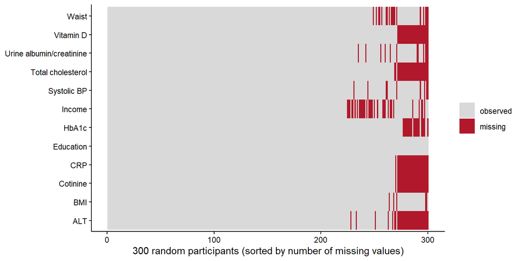

```r
set.seed(2026)
nhanes %>%
  select(SEQN, all_of(analysis_vars)) %>%
  slice_sample(n = 300) %>%
  mutate(across(-SEQN, is.na)) %>%
  mutate(n_missing = rowSums(pick(-SEQN))) %>%
  arrange(n_missing) %>%
  mutate(participant = row_number()) %>%
  select(-SEQN, -n_missing) %>%
  pivot_longer(-participant, names_to = "variable", values_to = "missing") %>%
  ggplot(aes(x = participant, y = variable, fill = missing)) +
  geom_tile() +
  scale_fill_manual(values = c(`FALSE` = "grey85", `TRUE` = "#B2182B"),
                    labels = c("observed", "missing")) +
  labs(x = "300 random participants (sorted by number of missing values)", y = NULL, fill = NULL)
```

Income has the most missing values (13.1%). We check whether this missingness depends on other variables:

```r
nhanes %>%
  group_by(education) %>%
  summarise(n = n(), pct_income_missing = round(mean(is.na(INDFMPIR)) * 100, 1))
```

```
## # A tibble: 6 × 3
##   education             n pct_income_missing
##   <ord>             <int>              <dbl>
## 1 <9th grade          292               23.3
## 2 9-11th grade        479               16.1
## 3 High school/GED    1283               14.8
## 4 Some college/AA    1836               12.4
## 5 College graduate+  2129               10.5
## 6 <NA>                  4               25
```

```r
nhanes %>%
  filter(!is.na(obese)) %>%
  group_by(obese) %>%
  summarise(n = n(), pct_income_missing = round(mean(is.na(INDFMPIR)) * 100, 1))
```

```
## # A tibble: 2 × 3
##   obese         n pct_income_missing
##   <fct>     <int>              <dbl>
## 1 Not obese  3490               13.2
## 2 Obese      2439               12.8
```

Income is missing more often in participants with a low education level (23% below 9th grade versus 11% for college graduates), but hardly differs between obese and non-obese adults.

## Type of missingness: MCAR, MAR or MNAR?

Lesson 2 distinguishes three types of missing data. We classify each source:

[output not shown]

## Imputation or not?

Lesson 2 describes several imputation methods: mean or median imputation, most-frequent-value imputation for categorical variables, constant imputation and kNN imputation. We decided **not to impute** in parts 1–3:

- The panels with much missing data (50–80%) are removed by the feature filter. Imputing them would mostly create artificial data.
- The variables we keep have at most 11% (laboratory) or 13% (income) missing values.
- A complete-case analysis guarantees that all 20 tests in part 3 are based on **the same participants**, so the results are comparable (lesson 2 warns that models fitted on different observations cannot be compared).

Complete-case analysis is only unbiased if the excluded participants do not differ systematically from the others. We check this for the participants used in part 3 (all 20 markers and cotinine available) versus the excluded ones:

```r
markers_part3 <- c("LBXGH", "LBXSGL", "LBDHDD", "LBXSTR", "LBXTC", "LBXSUA", "LBXMAGN",
                   "LBXSATSI", "LBXSASSI", "LBXSGTSI", "LBXSAL", "LBXHSCRP", "LBXWBCSI",
                   "LBDNENO", "LBXSCR", "URDACT", "LBXSBU", "LBXSHBG", "LBXVIDMS", "LBXSIR")

nhanes %>%
  filter(!is.na(BMXBMI)) %>%
  mutate(complete = if_else(if_all(all_of(c(markers_part3, "LBXCOT")), ~ !is.na(.x)),
                            "Complete case", "Excluded")) %>%
  group_by(complete) %>%
  summarise(n = n(), mean_age = mean(RIDAGEYR), pct_female = mean(sex == "Female") * 100,
            mean_bmi = mean(BMXBMI), pct_obese = mean(obese == "Obese") * 100)
```

```
## # A tibble: 2 × 6
##   complete          n mean_age pct_female mean_bmi pct_obese
##   <chr>         <int>    <dbl>      <dbl>    <dbl>     <dbl>
## 1 Complete case  5190     54.0       54.7     29.8      41.2
## 2 Excluded        739     53.5       55.8     30.0      40.9
```

The 5,190 complete cases and the 739 excluded participants are very similar in age (54.0 vs 53.5 years), sex (54.7% vs 55.8% women) and obesity (41.2% vs 40.9%), so excluding them is unlikely to bias the results.

For the machine learning in part 4, imputation may still be useful to keep more participants. In that case, the imputation (e.g. median or kNN) will be fitted on the **training set only** and then applied to the test set, to avoid data leakage (machine learning lecture).

# Step 1.8: selection of laboratory features

*What: five filters (387 → 101 features) and a variability check. Why: remove uninformative features with criteria that do not use any group label (required for part 3).*

The 387 laboratory variables are the high-dimensional part of the dataset, and we will use them for the multiple testing study (part 3) and as candidate predictors (part 4). We select the informative ones in five steps. **None of these steps uses an outcome or group label** (such as obesity), which is required for part 3: the filter must not favour features that differ between the groups we will compare.

```r
lab_vars <- codebook %>%
  filter(component == "Laboratory") %>%
  mutate(
    # label without the unit between brackets, e.g. "Blood lead (ug/dL)" -> "Blood lead"
    base_label = str_trim(str_remove(label, "\\s*\\(.*\\)\\s*$")),
    is_weight  = str_starts(variable, "WT"),
    is_comment = str_detect(label, regex("comment|cmt|comt", ignore_case = TRUE)),
    is_fasting_question = file == "FASTQX_L"
  )
```

**Step 1: keep only measurements.** We remove sample weights (`WT...`), comment codes (detection-limit flags, used in step 4) and the fasting questionnaire (`FASTQX_L`: hours since the last meal; not a biological measurement).

**Step 2: remove unit duplicates.** Many analytes are reported twice, in conventional and SI units (e.g. `LBXTC` in mg/dL and `LBDTCSI` in mmol/L). These are perfectly correlated, so we keep the first one of each pair (same file, same label apart from the unit).

```r
step1 <- lab_vars %>% filter(!is_weight, !is_comment, !is_fasting_question)
step2 <- step1 %>% filter(!duplicated(paste(file, base_label)))
```

**Step 3: less than 20% missing values.** This removes the subsample panels described in step 1.7, which would leave too few complete samples for multivariable analyses. The threshold falls in a natural gap: the remaining variables have at most 11% missing values, the next ones 33% (LDH) or more.

```r
pct_missing_lab <- colMeans(is.na(nhanes[, step2$variable]))
step3 <- step2 %>% filter(pct_missing_lab[variable] < 0.20)
```

**Step 4: enough distinct values.** For each variable, we compute the proportion of participants with the most frequent value. When this proportion is above 30%, the variable is either categorical (e.g. hepatitis serology: positive/negative) or mostly below the limit of detection. NHANES replaces values below the detection limit by one fixed value, the detection limit divided by √2. Such variables carry little quantitative information.

```r
modal_frequency <- function(x) {
  x <- x[!is.na(x)]
  max(table(x)) / length(x)
}
modal_freq <- sapply(nhanes[, step3$variable], modal_frequency)

# Which variables are removed and why?
tibble(variable = names(modal_freq), modal_freq = round(modal_freq, 2)) %>%
  filter(modal_freq > 0.30) %>%
  left_join(codebook %>% select(variable, label), by = "variable") %>%
  arrange(modal_freq) %>%
  knitr::kable()
```

| variable | modal_freq | label |
| --- | --- | --- |
| LBXBGM | 0.35 | Mercury, methyl (ug/L) |
| LBXAMH | 0.35 | Anti-Mullerian hormone (ng/mL) |
| LBXHCOT | 0.39 | Hydroxycotinine, Serum (ng/mL) |
| LBXCOT | 0.40 | Cotinine, Serum (ng/mL) |
| LBDEONO | 0.43 | Eosinophils number (1000 cells/uL) |
| LBDBANO | 0.51 | Basophils number (1000 cells/uL) |
| LBXNRBC | 0.51 | Nucleated red blood cells (/100 WBC) |
| LBXHA | 0.58 | Hepatitis A antibody |
| LBXHBS | 0.75 | Hepatitis B Surface Antibody |
| LBXVD2MS | 0.77 | 25OHD2 (nmol/L) |
| LBDHEG | 0.85 | Hepatitis E IgG (anti-HEV) |
| LBXIHG | 0.85 | Mercury, inorganic (ug/L) |
| LBXHBC | 0.94 | Hepatitis B core antibody |
| LBXSF5SI | 0.97 | 5,10-Methenyl-tetrahydrofolate (nmol/L) |
| LBXHCR | 0.98 | Hepatitis C RNA |
| LBDHCI | 0.98 | Hepatitis C Antibody (confirmed) |
| LBDHBG | 1.00 | Hepatitis B surface antigen |
| LBDHD | 1.00 | Hepatitis D antibody (anti-HDV) |
| LBXBGE | 1.00 | Mercury, ethyl (ug/L) |
| LBXSF3SI | 1.00 | 5-Formyl-tetrahydrofolate (nmol/L) |

```r
step4 <- step3 %>% filter(modal_freq[variable] <= 0.30)
```

**Step 5: detection limit and duplicate analytes.** For RBC folate forms, the detection limit depends on the sample, so values below it are not all identical and step 4 does not catch them. We therefore also look at the comment codes, which flag each value below the detection limit (code 1):

```r
lod_tbl <- lab_vars %>%
  filter(is_comment) %>%
  mutate(pct_below_lod = map_dbl(variable, ~ mean(nhanes[[.x]] == 1, na.rm = TRUE) * 100)) %>%
  select(variable, label, pct_below_lod) %>%
  arrange(desc(pct_below_lod))

# Comment codes of the features that are still in the selection after step 4
lod_tbl %>%
  filter(variable %in% c("LBDRF2LC", "LBDRF3LC", "LBDRF5LC", "LBDTHGLC")) %>%
  knitr::kable(digits = 1)
```

| variable | label | pct_below_lod |
| --- | --- | --- |
| LBDRF3LC | 5-Formyl-tetrahydrofolate, RBC cmt | 57.0 |
| LBDRF2LC | Folic acid, RBC cmt | 54.3 |
| LBDRF5LC | 5,10-Methenyl-tetrahydrofolate, RBC cmt | 24.4 |
| LBDTHGLC | Blood mercury, total comment code | 18.0 |

Folic acid and 5-formyl-tetrahydrofolate in red blood cells (`LBXRF2SI`, `LBXRF3SI`) are below the detection limit in more than half of the participants, so we remove them. For the other remaining features, at most 24% of the values are below the detection limit; we keep them.

Finally, total cholesterol was measured twice, in two different laboratory panels (`LBXTC` in `TCHOL_L` and `LBXSCH` in the biochemistry profile). These two measurements are almost identical, so we keep only `LBXTC`:

```r
cor(nhanes$LBXTC, nhanes$LBXSCH, use = "complete.obs")
```

```
## [1] 0.9901699
```

```r
lab_features <- setdiff(step4$variable, c("LBXRF2SI", "LBXRF3SI", "LBXSCH"))
```

```r
tibble(
  step = c("All laboratory variables",
           "1. Measurements only (no weights, comment codes, fasting questions)",
           "2. No unit duplicates",
           "3. < 20% missing values",
           "4. Most frequent value in <= 30% of participants",
           "5. Not mostly below detection limit, no duplicate analyte"),
  n_variables = c(nrow(lab_vars), nrow(step1), nrow(step2), nrow(step3), nrow(step4),
                  length(lab_features))
) %>% knitr::kable()
```

| step | n_variables |
| --- | --- |
| All laboratory variables | 387 |
| 1. Measurements only (no weights, comment codes, fasting questions) | 228 |
| 2. No unit duplicates | 184 |
| 3. < 20% missing values | 124 |
| 4. Most frequent value in <= 30% of participants | 104 |
| 5. Not mostly below detection limit, no duplicate analyte | 101 |

Lesson 2 also suggests removing features with (almost) no variability, using e.g. the coefficient of variation (CV = SD / mean). Fewer features means fewer tests, so a smaller multiple testing correction and more power.

```r
cv <- sapply(nhanes[, lab_features], function(x) sd(x, na.rm = TRUE) / mean(x, na.rm = TRUE))
summary(cv)
```

```
##    Min. 1st Qu.  Median    Mean 3rd Qu.    Max.
## 0.01776 0.14363 0.33347 0.70220 0.74196 7.86193
```

```r
head(sort(cv), 6)   # least variable features
```

```
##   LBXSNASI   LBXSOSSI      LBXMC   LBXSCLSI     LBXSCA     LBXSTP
## 0.01776297 0.01907573 0.02694570 0.02978444 0.04038280 0.06207607
```

The least variable features are sodium (CV 1.8%), osmolality, mean corpuscular hemoglobin concentration, chloride and calcium. Their low variability is not technical noise but **homeostasis**: the body keeps these values within narrow limits. They are measured precisely and can still differ between groups, so we keep them; no feature has a CV close to zero.

We keep **101 laboratory features**. They cover complete blood count, biochemistry (liver and kidney function, electrolytes, lipids), glycohemoglobin, fatty acids, folate forms, vitamin D, sex hormones, metals, inflammation (CRP) and urine albumin/creatinine.

# Step 1.9: normalisation and log2 transformation

*What: no normalisation; log2 transformation of right-skewed features. Why: lab values are absolute concentrations; log2 makes skewed values more symmetric for linear models.*

## Normalisation

In lesson 2, normalisation means removing unwanted technical variation between samples, such as differences in sequencing depth (RNA-seq) or RNA input (qPCR). **This step is not needed for our data**: each laboratory value is an absolute concentration, measured with a calibrated clinical assay under the quality control of the NHANES laboratories. There is no library size or input amount that differs between participants and would have to be corrected.

## Distributions and transformation

### Skewness

Most laboratory values are concentrations, which are typically right-skewed: many low values and a long tail of high values. Skewed variables violate the normality assumption of t-tests and linear models, and a few extreme values dominate the mean, the variance and the PCA. We quantify the asymmetry with the skewness: 0 for a symmetric distribution; above 1 indicates a strong right tail.

```r
skewness <- function(x) {
  x <- x[!is.na(x)]
  m <- mean(x)
  s <- sqrt(mean((x - m)^2))
  mean((x - m)^3) / s^3
}

skew_before <- sapply(nhanes[, lab_features], skewness)
summary(skew_before)
```

```
##    Min. 1st Qu.  Median    Mean 3rd Qu.    Max.
## -1.8138  0.5636  1.4465  3.6112  4.4623 40.3241
```

```r
sum(skew_before > 1)
```

```
## [1] 63
```

### Log2 transformation

We log2-transform every feature with a skewness above 1 (63 of the 101 features). On a log2 scale, a difference of 1 corresponds to a doubling of the concentration, which is easy to interpret (cf. log fold changes in the RNA-seq practical). One feature (eosinophil percentage) contains zeros; for that one, we add half of the smallest positive value before taking the log, similar to the pseudocount used for RNA-seq counts.

Features with a negative skewness (a tail to the left) are not log-transformed, because a log transformation would make the left tail longer.

```r
log_offset <- function(x) {
  if (min(x, na.rm = TRUE) > 0) 0 else min(x[x > 0], na.rm = TRUE) / 2
}

to_log <- names(skew_before)[skew_before > 1]

lab_log <- nhanes[, lab_features]
for (v in to_log) {
  lab_log[[v]] <- log2(lab_log[[v]] + log_offset(lab_log[[v]]))
}

skew_after <- sapply(lab_log, skewness)
sum(abs(skew_before) > 1)   # strongly skewed before
```

```
## [1] 65
```

```r
sum(abs(skew_after) > 1)    # strongly skewed after
```

```
## [1] 15
```

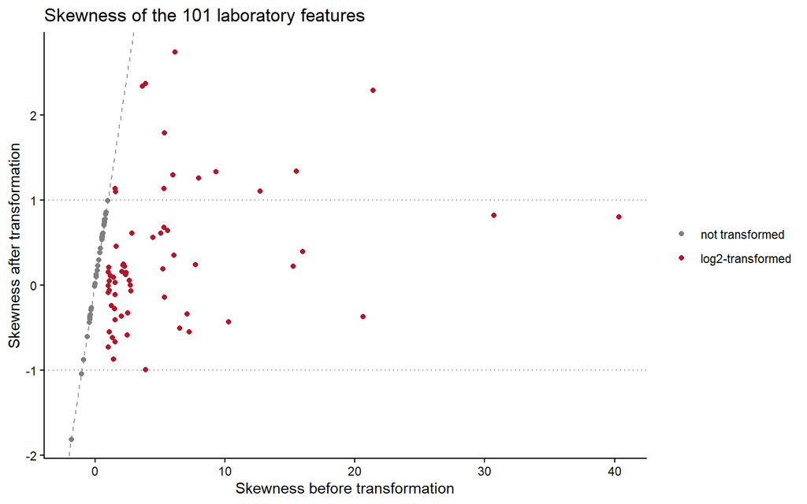

```r
tibble(variable = lab_features, before = skew_before, after = skew_after,
       transformed = lab_features %in% to_log) %>%
  ggplot(aes(x = before, y = after, colour = transformed)) +
  geom_abline(slope = 1, intercept = 0, linetype = "dashed", colour = "grey60") +
  geom_hline(yintercept = c(-1, 1), linetype = "dotted", colour = "grey60") +
  geom_point() +
  scale_colour_manual(values = c("FALSE" = "grey50", "TRUE" = "#B2182B"),
                      labels = c("not transformed", "log2-transformed")) +
  labs(x = "Skewness before transformation", y = "Skewness after transformation",
       colour = NULL, title = "Skewness of the 101 laboratory features")
```

The log transformation removes most of the asymmetry: the number of strongly skewed features (|skewness| > 1) drops from 65 to 15. The remaining skewed features are mostly variables whose tail is caused by a clinical subgroup, not by the measurement scale. For glycohemoglobin (HbA1c) and serum glucose, the tail consists of people with diabetes. We keep this tail because it is biology, not error, and take it into account when we choose statistical tests later.

Example of three typical features before and after transformation:

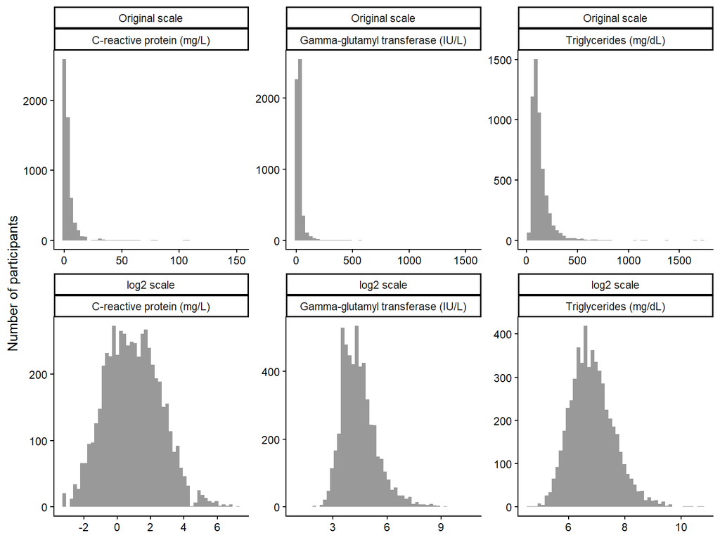

```r
examples <- c(LBXHSCRP = "C-reactive protein (mg/L)",
              LBXSGTSI = "Gamma-glutamyl transferase (IU/L)",
              LBXSTR   = "Triglycerides (mg/dL)")

bind_rows(
  nhanes[, names(examples)] %>% mutate(scale = "Original scale"),
  lab_log[, names(examples)] %>% mutate(scale = "log2 scale")
) %>%
  pivot_longer(-scale, names_to = "variable", values_to = "value") %>%
  mutate(variable = examples[variable],
         scale = factor(scale, levels = c("Original scale", "log2 scale"))) %>%
  ggplot(aes(x = value)) +
  geom_histogram(bins = 50, fill = "grey60") +
  facet_wrap(scale ~ variable, scales = "free", ncol = 3) +
  labs(x = NULL, y = "Number of participants")
```

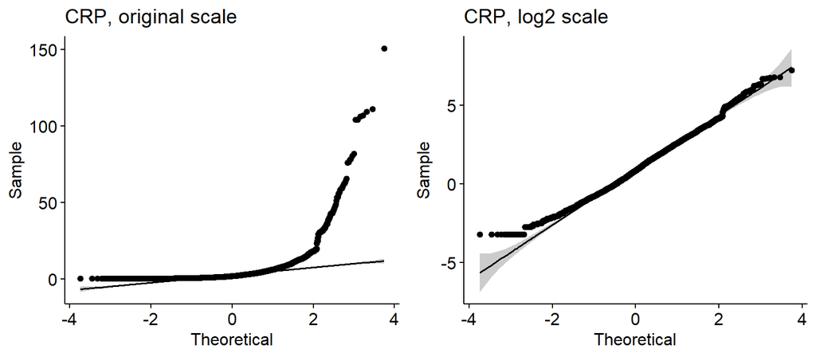

```r
ggarrange(
  ggqqplot(nhanes$LBXHSCRP[!is.na(nhanes$LBXHSCRP)], title = "CRP, original scale"),
  ggqqplot(lab_log$LBXHSCRP[!is.na(lab_log$LBXHSCRP)], title = "CRP, log2 scale"),
  ncol = 2
)
```

# Step 1.10: outliers

*What: ranges, boxplots, IQR and z-score rules, BMI consistency check. Why: guiding question 3 — technical error or interesting biology?*

## Clinical measurements

Unlike the blood pressure values in the cardiovascular practical (with values such as 14/7 instead of 140/70), the clinical measurements here have no impossible values. The extremes are rare but physiologically possible:

```r
nhanes %>%
  select(BMXBMI, BMXWT, BMXHT, BMXWAIST, sbp, dbp) %>%
  pivot_longer(everything(), names_to = "variable") %>%
  group_by(variable) %>%
  summarise(n = sum(!is.na(value)), min = min(value, na.rm = TRUE),
            median = median(value, na.rm = TRUE), max = max(value, na.rm = TRUE))
```

```
## # A tibble: 6 × 5
##   variable     n   min median   max
##   <chr>    <int> <dbl>  <dbl> <dbl>
## 1 BMXBMI    5929  11.1   28.5  74.8
## 2 BMXHT     5956 133    166.  201.
## 3 BMXWAIST  5726  60     99.5 187
## 4 BMXWT     5942  27.9   79.9 248.
## 5 dbp       5824  34     74   139
## 6 sbp       5824  70    121.  232.
```

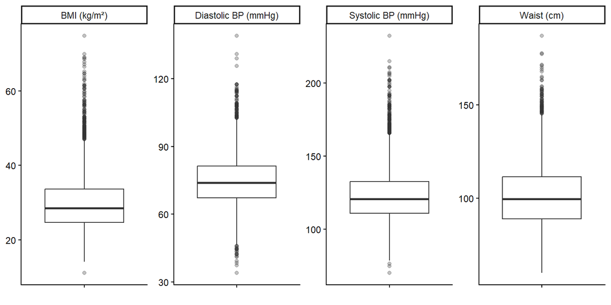

```r
nhanes %>%
  select(`BMI (kg/m²)` = BMXBMI, `Waist (cm)` = BMXWAIST,
         `Systolic BP (mmHg)` = sbp, `Diastolic BP (mmHg)` = dbp) %>%
  pivot_longer(everything(), names_to = "variable") %>%
  ggplot(aes(x = "", y = value)) +
  geom_boxplot(outlier.alpha = 0.3) +
  facet_wrap(~ variable, scales = "free_y", nrow = 1) +
  labs(x = NULL, y = NULL)
```

Lesson 2 describes two common rules to flag outliers: the **IQR rule** (below Q1 − 1.5 × IQR or above Q3 + 1.5 × IQR, as used by `boxplot()`) and the **z-score rule** (more than 3 SD from the mean). We count the flagged values per variable:

```r
outlier_tbl <- map_dfr(names(continuous_vars), function(lab) {
  x <- na.omit(nhanes[[continuous_vars[[lab]]]])
  q <- quantile(x, c(0.25, 0.75))
  iqr <- q[[2]] - q[[1]]
  tibble(variable = lab, n = length(x),
         n_iqr_outliers = sum(x < q[[1]] - 1.5 * iqr | x > q[[2]] + 1.5 * iqr),
         n_z_above_3 = sum(abs((x - mean(x)) / sd(x)) > 3))
})
knitr::kable(outlier_tbl)
```

| variable | n | n_iqr_outliers | n_z_above_3 |
| --- | --- | --- | --- |
| Age (years) | 6023 | 0 | 0 |
| BMI (kg/m²) | 5929 | 171 | 75 |
| Waist circumference (cm) | 5726 | 78 | 37 |
| Systolic BP (mmHg) | 5824 | 154 | 66 |
| Diastolic BP (mmHg) | 5824 | 101 | 48 |
| Income-to-poverty ratio | 5236 | 0 | 0 |

The IQR rule flags 171 BMI values (2.9%) and 154 systolic blood pressures (2.6%), nearly all on the high side. For right-skewed variables, the IQR rule always flags part of the long tail. These participants have severe obesity or hypertension: they are exactly the group our research question is about, not measurement errors. As lesson 2 states, an observation should not be removed simply because it appears to be an outlier.

As an internal consistency check, we recompute the BMI from the measured weight and height. The differences are smaller than 0.05 kg/m², i.e. only rounding:

```r
bmi_recomputed <- nhanes$BMXWT / (nhanes$BMXHT / 100)^2
summary(abs(bmi_recomputed - nhanes$BMXBMI))
```

```
##    Min. 1st Qu.  Median    Mean 3rd Qu.    Max.     NAs
## 0.00000 0.01186 0.02472 0.02452 0.03672 0.04996      94
```

**Decision**: we keep all clinical values. A BMI of 74.8 or a systolic blood pressure of 232 mmHg is extreme but occurs in severe obesity and hypertension; removing these values would remove exactly the people that are clinically most relevant.

## Laboratory features

After log transformation, we count per feature how many values lie more than 5 standard deviations from the mean:

```r
lab_z <- scale(lab_log)
n_extreme <- colSums(abs(lab_z) > 5, na.rm = TRUE)
head(sort(n_extreme, decreasing = TRUE), 8)
```

```
## LBXEOPCT LBXSF2SI    LBXGH   LBXSGL   LBXESO   LBXRDW   LBXPD3   LBXES1
##       33       32       26       25       23       22       16       13
```

The features with the most extreme values are biologically interpretable. HbA1c (`LBXGH`) and serum glucose (`LBXSGL`) are extreme in uncontrolled diabetes. Serum folic acid (`LBXSF2SI`) is extreme in people taking folic acid supplements, and estrone (`LBXESO`) in women using hormone therapy. These are true values, not technical errors, so **we keep them**. In the next parts we will check the influence of extreme observations, e.g. with Cook’s distance (as in the statistics practical) or with rank-based or robust methods.

Whether whole *samples* behave unlike the rest is checked with the PCA in the next section.

# Step 1.11: standardisation, PCA and clustering

*What: z-score standardisation, PCA, hierarchical clustering and a correlation heatmap. Why: guiding question 5 — do samples cluster by biology or by a technical factor?*

## Standardisation

The laboratory features have very different units and ranges (e.g. sodium around 140 mmol/L, CRP around 2 mg/L). In methods that use distances or variances, such as PCA, clustering and heatmaps, the features with the largest values would dominate. We therefore **standardise** (z-score: subtract the mean and divide by the SD) before these analyses, so that every feature has mean 0 and SD 1.

The boxplots show the 20 markers selected a priori for part 3, before and after standardisation:

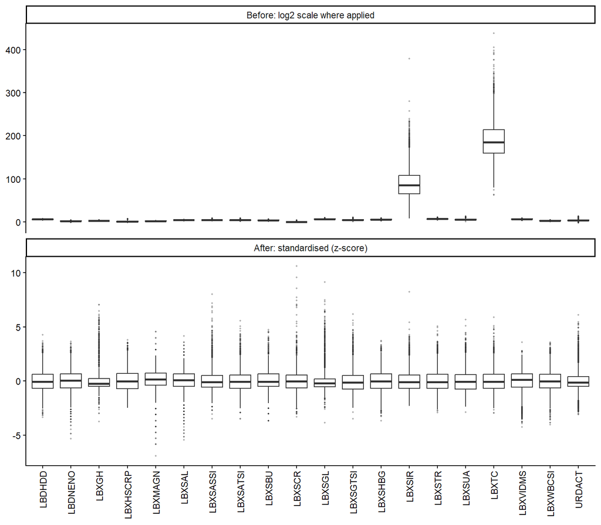

```r
std_before <- lab_log[, markers_part3]
std_after  <- as_tibble(scale(std_before))

bind_rows(
  std_before %>% pivot_longer(everything()) %>% mutate(scale = "Before: log2 scale where applied"),
  std_after  %>% pivot_longer(everything()) %>% mutate(scale = "After: standardised (z-score)")
) %>%
  drop_na(value) %>%
  mutate(scale = factor(scale, levels = c("Before: log2 scale where applied",
                                          "After: standardised (z-score)"))) %>%
  ggplot(aes(x = name, y = value)) +
  geom_boxplot(outlier.size = 0.3, outlier.alpha = 0.3) +
  facet_wrap(~ scale, ncol = 1, scales = "free_y") +
  labs(x = NULL, y = NULL) +
  theme(axis.text.x = element_text(angle = 90, vjust = 0.5, hjust = 1))
```

Two remarks:

- Standardisation is used for **exploration** (PCA, heatmaps). The regression models in parts 2 and 3 use the log2 values, so the effects stay interpretable (e.g. “CRP is 2.5 times higher”).
- In part 4 (machine learning), standardisation will be fitted on the **training set only** and then applied to the test set. Standardising the whole dataset before splitting would leak information from the test set into the model (data leakage, machine learning lecture).

## PCA: do samples cluster by biology or by technical factors?

**What is a PCA?** A PCA summarises many variables into a few new ones, the *principal components* (PCs). Each PC is a weighted combination of the original variables. PC1 is the direction in which participants differ the most, PC2 the next largest direction (perpendicular to PC1), and so on. This way, the main patterns in 101 blood markers can be shown in a two-dimensional plot.

- **Score**: the value of one participant on a PC (a dot in the PCA plot).
- **Loading**: how much each blood marker contributes to a PC, and in which direction.
- **Explained variance**: the share of all differences between participants captured by a PC.

The markers are standardised first, so that each marker counts equally regardless of its unit. The sign of a PC is arbitrary: only the differences between groups matter.

**Why we use it:** to check whether participants cluster by biology (age, sex, BMI) or by a technical factor (exam period, exam session). A technical factor driving a PC would point to a measurement problem (batch effect).

We perform a PCA on the 101 log-transformed laboratory features. PCA requires complete data, so we use the 4,261 participants without any missing laboratory value (70.7% of the study population). The features have very different units, so they are standardised (mean 0, SD 1) with `scale. = TRUE`. Otherwise features with a large variance (e.g. platelet count) would dominate the components.

```r
pca_input <- lab_log %>%
  mutate(SEQN = nhanes$SEQN) %>%
  drop_na()

pca_res <- prcomp(pca_input %>% select(-SEQN), center = TRUE, scale. = TRUE)

pca_scores <- as_tibble(pca_res$x[, 1:10]) %>%
  mutate(SEQN = pca_input$SEQN) %>%
  left_join(nhanes %>% select(SEQN, RIDAGEYR, age_group, sex, race_eth, BMXBMI,
                              bmi_cat, exam_period, exam_session),
            by = "SEQN")

nrow(pca_scores)
```

```
## [1] 4261
```

### Explained variance

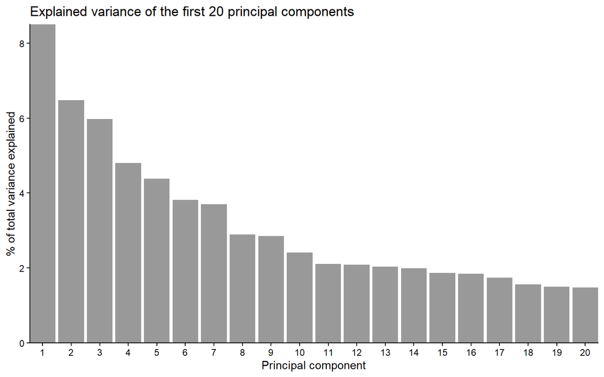

```r
tibble(pc = 1:20,
       pct_var = (pca_res$sdev^2 / sum(pca_res$sdev^2) * 100)[1:20]) %>%
  ggplot(aes(x = pc, y = pct_var)) +
  geom_col(fill = "grey60") +
  scale_x_continuous(breaks = 1:20, expand = c(0, 0)) +
  scale_y_continuous(expand = c(0, 0)) +
  labs(x = "Principal component", y = "% of total variance explained",
       title = "Explained variance of the first 20 principal components")
```

The first components explain only a modest part of the variance (PC1 8.5%, PC2 6.5%, PC3 6.0%; 30% for the first five). This is expected: the panel combines many largely independent physiological systems (blood count, liver, kidney, hormones, nutrition), unlike e.g. a transcriptome where many genes are co-regulated.

### PC1 versus PC2, coloured by biological and technical factors

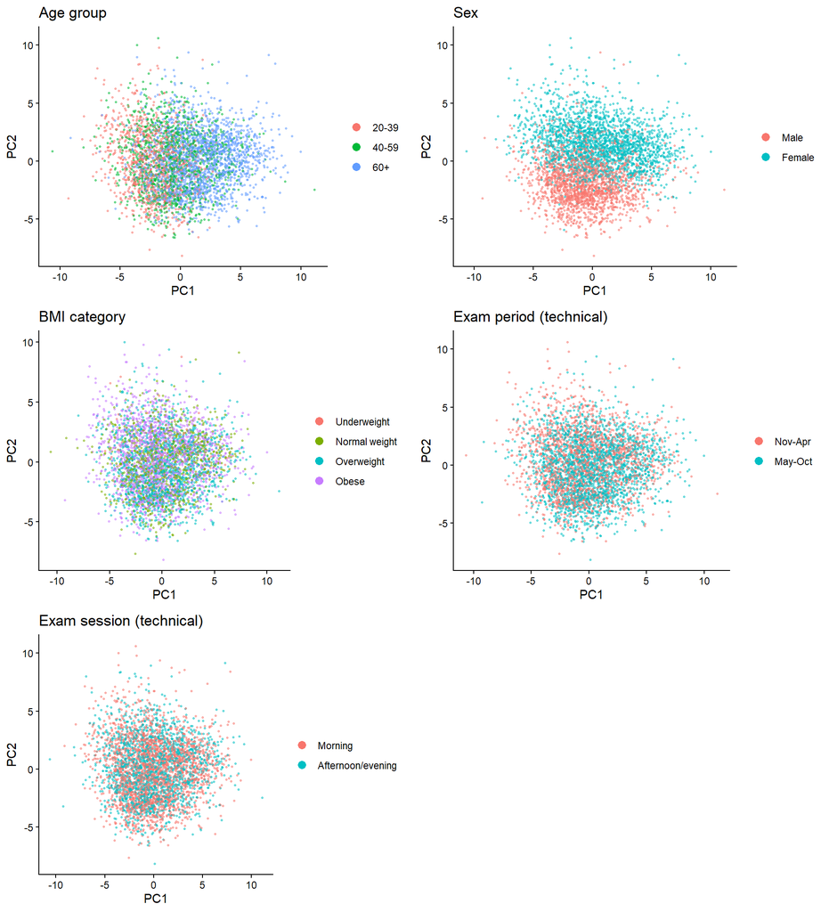

```r
pca_plot <- function(colour_var, title) {
  ggplot(pca_scores %>% drop_na(all_of(colour_var)),
         aes(x = PC1, y = PC2, colour = .data[[colour_var]])) +
    geom_point(size = 0.6, alpha = 0.5) +
    labs(title = title, colour = NULL) +
    guides(colour = guide_legend(override.aes = list(size = 3, alpha = 1)))
}

ggarrange(
  pca_plot("age_group", "Age group"),
  pca_plot("sex", "Sex"),
  pca_plot("bmi_cat", "BMI category"),
  pca_plot("exam_period", "Exam period (technical)"),
  pca_plot("exam_session", "Exam session (technical)"),
  ncol = 2, nrow = 3
)
```

### Which factors are associated with the principal components?

To quantify the plots, we fit a linear model of each of the first five components on each factor and report the R² (the proportion of the variance of the component explained by the factor).

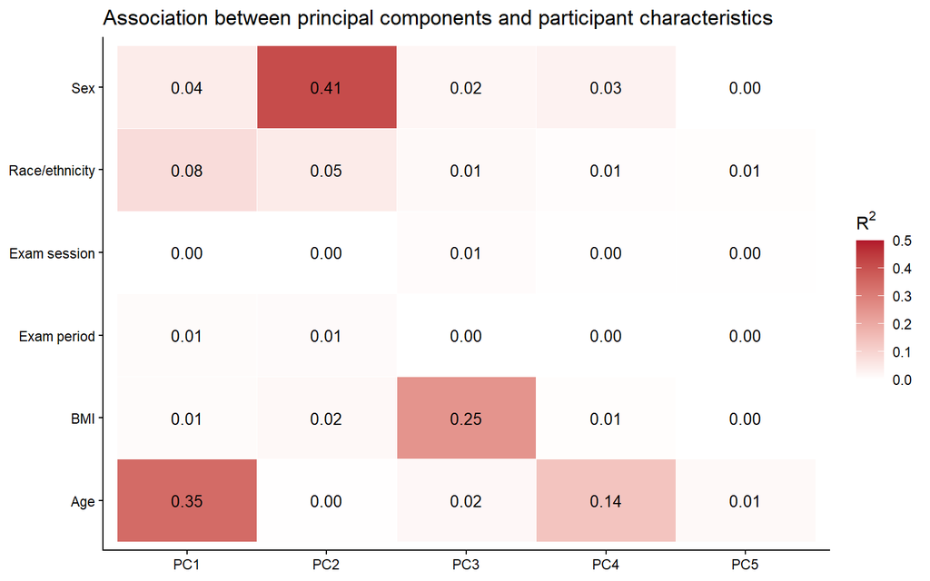

```r
pc_factors <- c(Age = "RIDAGEYR", Sex = "sex", `Race/ethnicity` = "race_eth",
                BMI = "BMXBMI", `Exam period` = "exam_period", `Exam session` = "exam_session")

pc_assoc <- expand_grid(pc = paste0("PC", 1:5), factor = pc_factors) %>%
  mutate(r2 = map2_dbl(pc, factor, ~ summary(lm(reformulate(.y, response = .x),
                                                data = pca_scores))$r.squared),
         factor_label = names(pc_factors)[match(factor, pc_factors)])

ggplot(pc_assoc, aes(x = pc, y = factor_label, fill = r2)) +
  geom_tile(colour = "white") +
  geom_text(aes(label = sprintf("%.2f", r2)), size = 3.5) +
  scale_fill_gradient(low = "white", high = "#B2182B", limits = c(0, 0.5)) +
  labs(x = NULL, y = NULL, fill = expression(R^2),
       title = "Association between principal components and participant characteristics")
```

BMI, the biology we care about, is not visible in PC1 and PC2 but in PC3 (see the table above). The PC3 scores shift steadily from normal weight to obesity. The sign of a principal component is arbitrary, so whether PC3 goes up or down with BMI has no meaning:

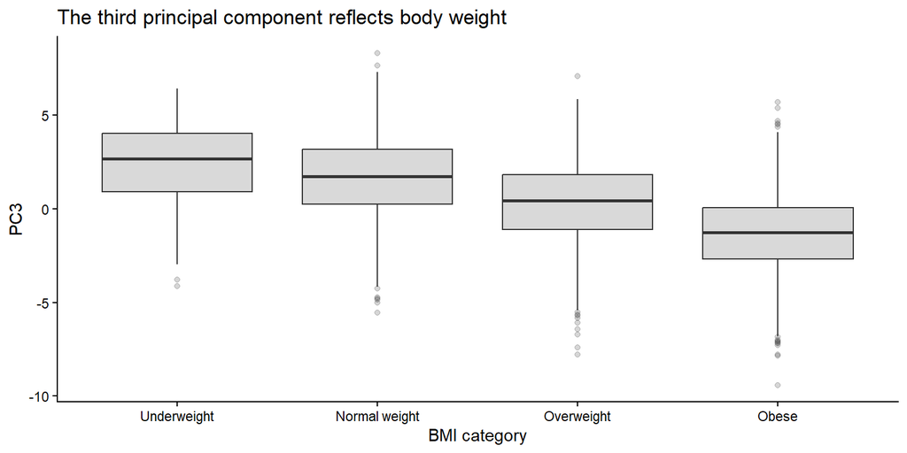

```r
pca_scores %>%
  drop_na(bmi_cat) %>%
  ggplot(aes(x = bmi_cat, y = PC3)) +
  geom_boxplot(fill = "grey85", outlier.alpha = 0.2) +
  labs(x = "BMI category", y = "PC3",
       title = "The third principal component reflects body weight")
```

### Which features drive PC1 and PC2?

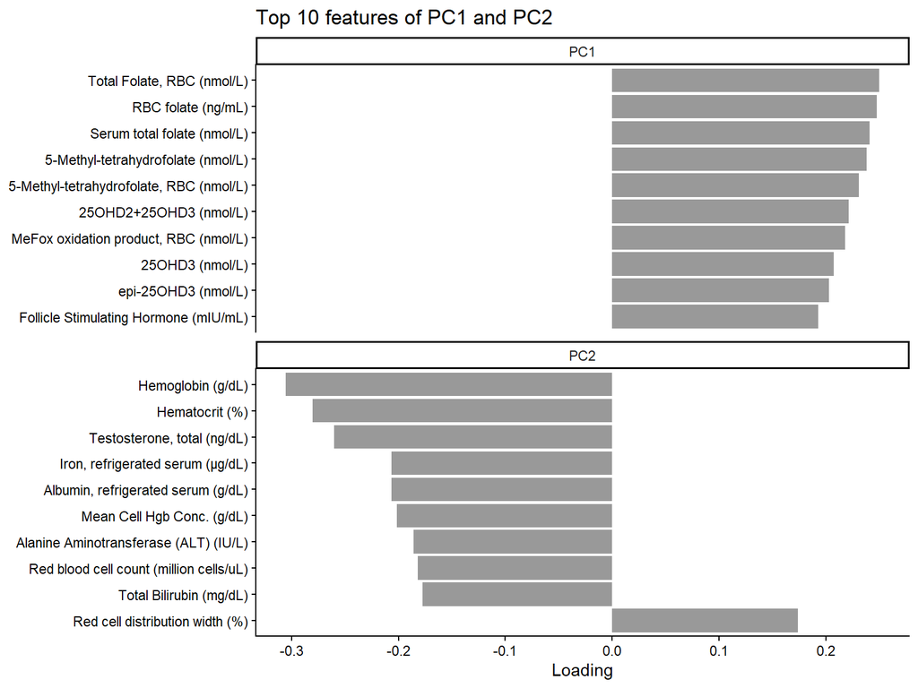

```r
as_tibble(pca_res$rotation[, 1:2], rownames = "variable") %>%
  left_join(codebook %>% select(variable, label), by = "variable") %>%
  pivot_longer(c(PC1, PC2), names_to = "pc", values_to = "loading") %>%
  group_by(pc) %>%
  slice_max(abs(loading), n = 10) %>%
  ungroup() %>%
  mutate(label_pc = paste(pc, label, sep = ": ")) %>%
  ggplot(aes(x = loading, y = reorder(label_pc, abs(loading)))) +
  geom_col(fill = "grey60") +
  facet_wrap(~ pc, scales = "free_y", ncol = 1) +
  scale_y_discrete(labels = function(x) str_remove(x, "^PC[0-9]+: ")) +
  labs(x = "Loading", y = NULL, title = "Top 10 features of PC1 and PC2")
```

**Interpretation.**

- **PC1 is mainly age** (R² = 0.35). It is driven by folate forms and vitamin D, which are higher in older adults, among other things because supplement use increases with age.
- **PC2 is mainly sex** (R² = 0.41). It is driven by hemoglobin, hematocrit, red blood cell count, testosterone and serum iron, which are all higher in men.
- **PC3 is associated with BMI** (R² = 0.25). This is a first indication that body weight is linked to a broad laboratory profile, which we will study in parts 2 and 3.
- **The technical factors do not structure the data.** The exam period (winter vs summer) and the exam session (morning vs afternoon) explain at most about 1% of the variance of any of the first five components.
- No sample lies further than 5 standard deviations from the centre on PC1 or PC2. We therefore see no sign of technically failed samples.

The samples thus cluster by biology (age, sex, BMI), not by a technical batch factor. Because age and sex dominate the laboratory profile, **they are important potential confounders** and must be included as covariates in the analyses of parts 2 and 3.

## Hierarchical clustering of the participants

Lesson 2 uses a heatmap with hierarchical clustering to check whether samples cluster according to biology or according to a technical factor. We cluster 500 randomly chosen participants (from the complete cases of the PCA) on their 101 standardised laboratory features, with Manhattan distance and Ward clustering as in the neuroblastoma example of lesson 2. Values are truncated at ±3 SD so that a few extreme values do not dominate the colour scale.

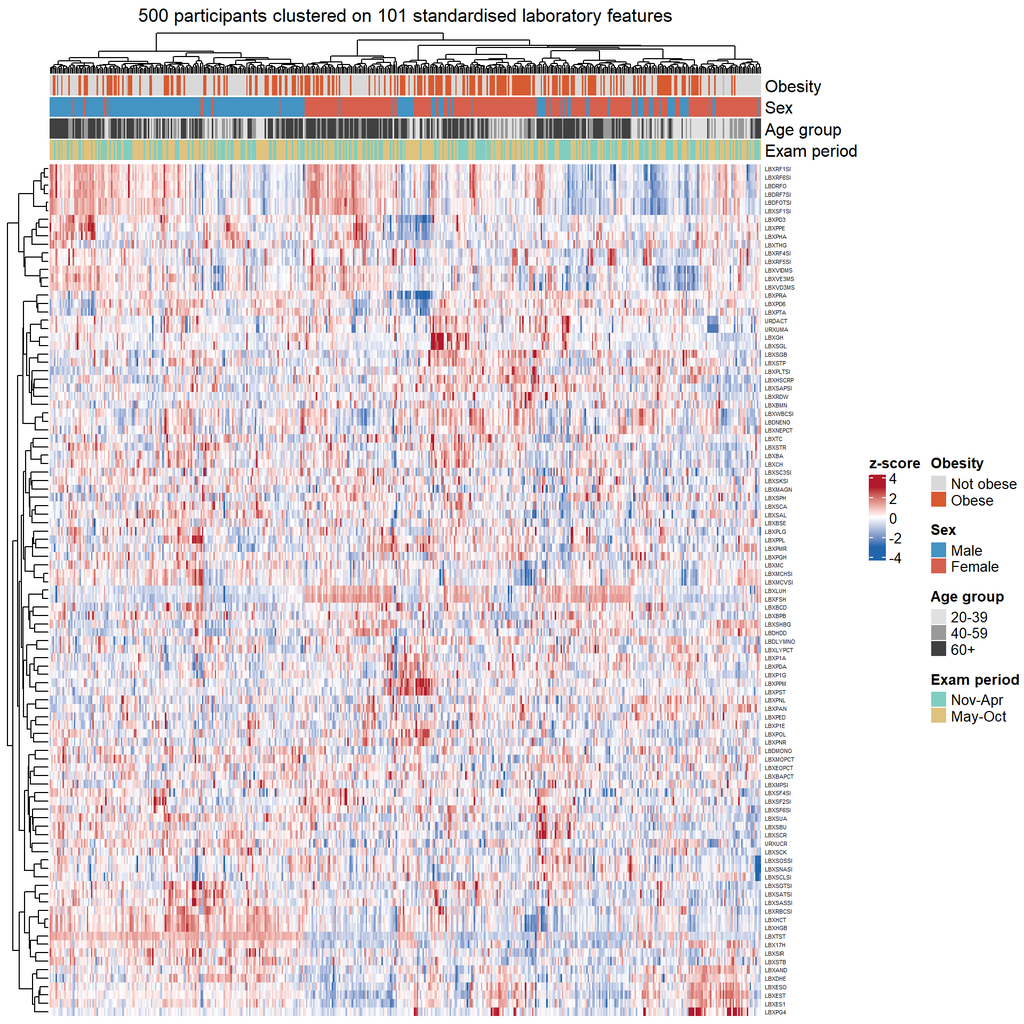

```r
set.seed(2026)
hm_rows <- sample(nrow(pca_input), 500)

hm_mat <- pca_input %>% select(-SEQN) %>% as.matrix() %>% scale()
hm_mat <- t(hm_mat[hm_rows, ])          # features in rows, participants in columns
hm_mat[hm_mat > 3] <- 3
hm_mat[hm_mat < -3] <- -3

hm_meta <- tibble(SEQN = pca_input$SEQN[hm_rows]) %>%
  left_join(nhanes %>% select(SEQN, obese, sex, age_group, exam_period), by = "SEQN")

hm_annotation <- HeatmapAnnotation(
  Obesity       = hm_meta$obese,
  Sex           = hm_meta$sex,
  `Age group`   = hm_meta$age_group,
  `Exam period` = hm_meta$exam_period,
  col = list(Obesity       = c("Not obese" = "grey85", "Obese" = "#D85A30"),
             Sex           = c("Male" = "#4393C3", "Female" = "#D6604D"),
             `Age group`   = c("20-39" = "#E0E0E0", "40-59" = "#999999", "60+" = "#404040"),
             `Exam period` = c("Nov-Apr" = "#80CDC1", "May-Oct" = "#DFC27D"))
)

Heatmap(hm_mat,
        name = "z-score",
        col = circlize::colorRamp2(c(-3, 0, 3), c("#2166AC", "white", "#B2182B")),
        top_annotation = hm_annotation,
        clustering_distance_columns = "manhattan", clustering_method_columns = "ward.D2",
        clustering_distance_rows = "euclidean", clustering_method_rows = "ward.D2",
        show_column_names = FALSE,
        row_names_gp = grid::gpar(fontsize = 4),
        column_title = "500 participants clustered on 101 standardised laboratory features")
```

The participants do not split into sharply separated groups: the laboratory profile varies gradually, as expected for a general population sample (unlike, e.g., tumour subtypes). The clusters partly follow sex and obesity, in line with the PCA, while the exam period is mixed across all clusters. This confirms that there is **no technical batch effect**, so batch correction (optional step 4 of lesson 2) is not needed.

## Correlation structure of the laboratory features

A clustered correlation heatmap shows which features carry overlapping information. This matters for interpreting multiple tests (part 3: tests on correlated features are not independent) and feature importance (part 4).

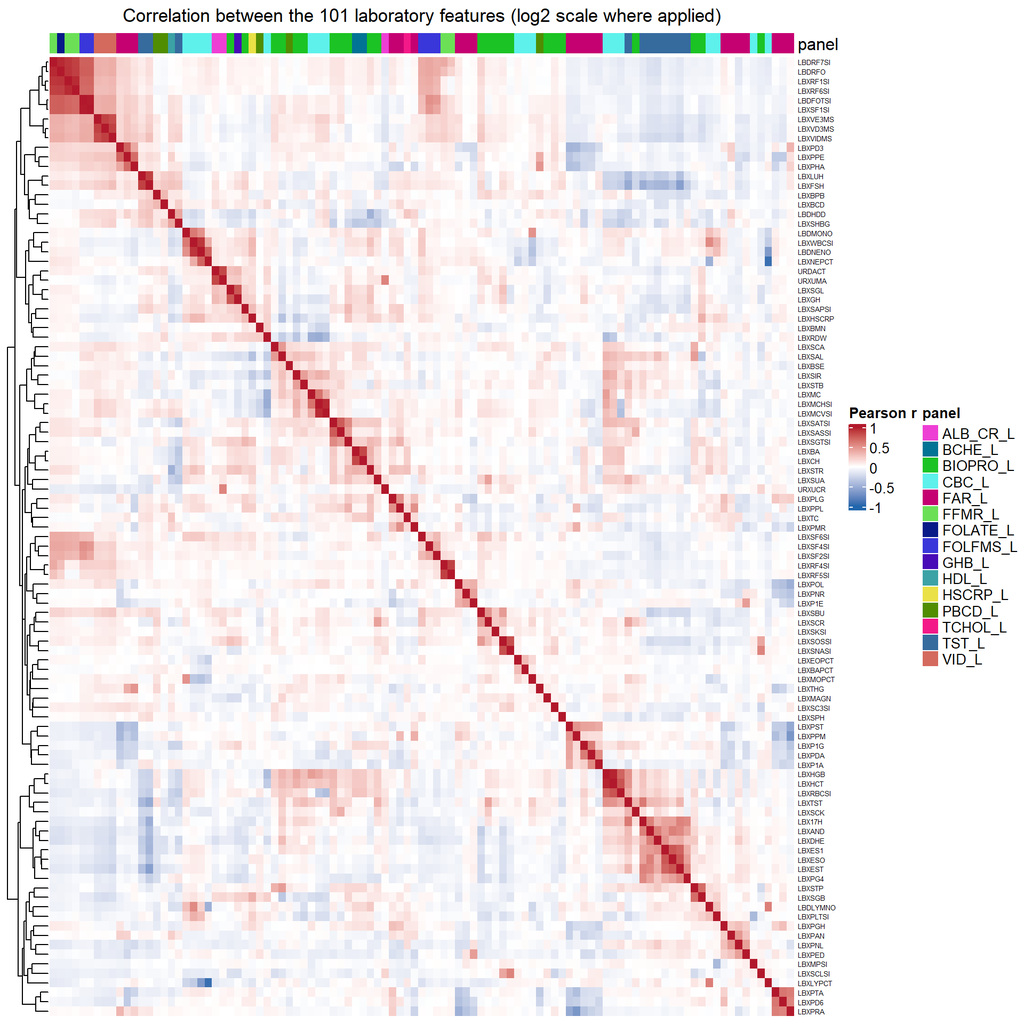

```r
cor_mat <- cor(lab_log, use = "pairwise.complete.obs")
lab_panel <- codebook$file[match(colnames(cor_mat), codebook$variable)]

Heatmap(cor_mat,
        name = "Pearson r",
        col = circlize::colorRamp2(c(-1, 0, 1), c("#2166AC", "white", "#B2182B")),
        top_annotation = HeatmapAnnotation(panel = lab_panel),
        show_column_names = FALSE,
        row_names_gp = grid::gpar(fontsize = 5),
        show_column_dend = FALSE,
        column_title = "Correlation between the 101 laboratory features (log2 scale where applied)")
```

The features form clear modules that correspond to physiological systems and laboratory panels: red blood cell indices, white blood cell counts, folate forms, fatty acids, sex hormones, and liver enzymes. Within these modules, correlations are high. The highest values (r ≈ 0.96–0.97, e.g. hemoglobin–hematocrit and the two RBC folate assays) are between closely related but distinct measurements, not between pure duplicates.

# Step 1.12: save the preprocessed data

*What: save the cleaned data and two tables. Why: parts 2–4 start from exactly the same data (reproducibility).*

We save the following files in the `output` folder for the next parts:

- `nhanes_clean.rds`: the study population (6,023 adults) with the recoded clinical variables and the 101 laboratory features on their **original** scale. The original scale is needed for clinical definitions, e.g. diabetes as HbA1c ≥ 6.5%.
- `nhanes_lab_log2.rds`: the same 101 laboratory features, **log2-transformed** where applicable, to be used for statistical testing and PCA.

A table with the selected features and their transformation is saved as `lab_features.csv`.

```r
clinical_vars <- c("SEQN", "sex", "RIDAGEYR", "age_group", "race_eth", "education",
                   "INDFMPIR", "exam_period", "exam_session",
                   "BMXWT", "BMXHT", "BMXBMI", "bmi_cat", "obese", "BMXWAIST",
                   "abdominal_obese", "LBXCOT", "smoker",
                   "sbp", "dbp", "ALQ111", "ALQ121", "ALQ130")

nhanes_clean <- nhanes %>% select(all_of(clinical_vars), all_of(lab_features))
nhanes_lab_log2 <- lab_log %>% mutate(SEQN = nhanes$SEQN, .before = 1)

lab_info <- tibble(variable = lab_features) %>%
  left_join(codebook %>% select(variable, label, file), by = "variable") %>%
  mutate(pct_missing = round(colMeans(is.na(nhanes[, lab_features])) * 100, 1),
         skew_before = round(skew_before[variable], 2),
         log2_transformed = variable %in% to_log,
         skew_after = round(skew_after[variable], 2))

saveRDS(nhanes_clean, file.path(output_dir, "nhanes_clean.rds"))
saveRDS(nhanes_lab_log2, file.path(output_dir, "nhanes_lab_log2.rds"))
write_csv(lab_info, file.path(output_dir, "lab_features.csv"))

# The 20 markers selected a priori for part 3
write_csv(tibble(variable = markers_part3) %>%
            left_join(codebook %>% select(variable, label), by = "variable"),
          file.path(output_dir, "markers_part3.csv"))

dim(nhanes_clean)
```

```
## [1] 6023  124
```

```r
dim(nhanes_lab_log2)
```

```
## [1] 6023  102
```

# Summary: answers to the guiding questions

**How many samples and features, and which variable types?** The raw data contain 11,933 participants and 486 variables: 27 demographic, 32 examination, 387 laboratory and 40 questionnaire variables. 237 are numeric measurements (continuous, e.g. laboratory values and BMI, or discrete, e.g. age and number of drinks). 84 are binary or categorical codes: nominal, e.g. sex and race/ethnicity, or ordinal, e.g. education and alcohol frequency; these were converted to (ordered) factors. 155 are not features (identifier, survey design variables, comment codes), and 10 are constant or empty.

**Study population.** We analyse 6,023 non-pregnant adults (≥ 20 years) who were both interviewed and examined.

**Where are the missing values, why, and how did we handle them?** Most missingness is planned: subsample panels (fasting, PFAS, VOCs), age- or sex-specific components, and questionnaire skip patterns. It is therefore unrelated to the participants’ characteristics. We did not impute. Instead, we selected laboratory features with less than 20% missing values and will use complete cases per analysis. Special codes (refused/don’t know) were recoded to `NA`.

**Samples or features that behave unlike the rest?** Clinical extremes (BMI up to 74.8, systolic BP up to 232 mmHg) are plausible and kept. Extreme laboratory values correspond to clinical subgroups (diabetes, supplement or hormone use) and are kept. The PCA shows no outlying samples. Features that are mostly below the detection limit, categorical or duplicated were removed.

**Preprocessing steps (in the order of lesson 2).** Selection of 101 laboratory features with five label-independent filters; a log2 transformation of the 63 right-skewed features; standardisation within the PCA. Normalisation as for RNA-seq is not needed: each laboratory value is an absolute, calibrated concentration.

**Do samples cluster by biology or by a technical factor?** By biology. PC1 reflects age, PC2 sex and PC3 BMI, the biology of interest for our research question. The exam period and session explain at most about 1% of the variance of any of the first five components.

**Order and leakage.** Filtering, log transformation and standardisation were done without using the outcome (obesity), so they cannot bias the tests of part 3. For part 4, standardisation and any imputation will be fitted on the training set only.

**Is the dataset suitable for the next parts?** Yes. For our research question (obesity), all variables are available: the outcome (BMI), the explanatory variables and confounders of part 2 (race/ethnicity, sex, age, income), the confounders of part 3 (age, sex, race/ethnicity, smoking) and the 101 laboratory features. There are 5,929 adults with a BMI (41.1% obese), 5,824 with a blood pressure measurement and 5,371–5,870 with each laboratory feature (4,261 with all 101 features). This is ample for multivariable models (part 2), a multiple testing study over 101 features (part 3) and a machine learning model with a separate test set (part 4). Age and sex must be included as covariates because they dominate the laboratory profile.

**Limitation.** NHANES uses a complex, stratified sampling design with oversampling of some groups. Flegal et al. used the sample weights (`WTMEC2YR`) to obtain estimates that represent the US population. We do not use these weights, so our results describe associations within this sample and are not population prevalence estimates.